# qPCR mycorrhiza - additional genes

zagor

2025-10-20

```r
rm(list = ls(all = TRUE))
gc()
```

```
##           used (Mb) gc trigger (Mb) max used (Mb)
## Ncells  617647 33.0    1421022 75.9   686457 36.7
## Vcells 1162333  8.9    8388608 64.0  1877161 14.4
```

# 1 packages

```r
# %>%
library(magrittr)
library(ggplot2)


`%!in%` = Negate(`%in%`)
```

# 2 params

```r
col = RColorBrewer::brewer.pal(8, 'Paired')[c(3,4, 5,6, 7, 8)]

my_dir = file.path("..", "reports", "qPCR_mycorrhiza")
if (!dir.exists(my_dir)) {
  dir.create(my_dir)
}

fr = file.path('..', 'output',  'qPCRmycorrhiza_EMM_stat.txt')
file.create(fr)
```

```
## [1] TRUE
```

```r
dodge = position_dodge(width = 0.5)
p = rev(col)
```

# 3 f-ctions

## 3.1 summary stat

```r
summary_stats <- function(df, measurevar, groupvars, conf.level = 0.95) {
  df %>%
    dplyr::group_by(across(all_of(groupvars))) %>%
    dplyr::summarise(
      N = sum(!is.na(.data[[measurevar]])),
      mean = mean(.data[[measurevar]], na.rm = TRUE),
      sd = sd(.data[[measurevar]], na.rm = TRUE),
      .groups = "drop"
    ) %>%
    dplyr::mutate(
      se = sd / sqrt(N),
      ci = se * qt(conf.level/2 + 0.5, N - 1)
    )
}
```

## 3.2 scale to the average of the reference group

```r
process_data <- function(df, groupvars, measurevar, scale_treatment = "noninoculated") {

  df.long = df %>%
    tidyr::pivot_longer(cols = 3:ncol(df), names_to = "transcript",
                        values_to = measurevar, values_drop_na = TRUE)
  data.SE = summary_stats(df.long, measurevar, groupvars)
  scale_reference = data.SE %>%
    dplyr::filter(Treatment == scale_treatment) %>%
    dplyr::select(Genotype, transcript, mean) %>%
    dplyr::rename(scale_mean = mean)
  df.scaled <- dplyr::left_join(df.long, scale_reference, by = c("Genotype", "transcript")) %>%
    dplyr::mutate(scaled = .data[[measurevar]] / scale_mean) %>%
    dplyr::select(-scale_mean)
  df.scaled = df.scaled %>%
    dplyr::arrange(dplyr::desc(transcript), dplyr::desc(Treatment))



  return(list(
    amf = df.scaled

  ))
}
```

## 3.3 Generalized Linear Model, with Estimated marginal means followed by pairwise comparisons

- fit a Gamma GLM on the subset for that transcript; model coefficients are on the log scale
- compute heteroscedasticity‑consistent (HC3) covariance for the GLM coefficients
- ompute estimated marginal means using the robust vcov so SEs reflect heteroscedasticity
- pairwise comparisons with the multivariate‑t simultaneous adjustment that uses the supplied covariance
- residual diagnostics and plotting: simulate standardized residuals for the model, produce diagnostic output
- FDR‑adjusted p‑values across all contrasts from all transcrip in this case are not feasible
  - mixing two different multiple‑testing corrections and produces results that are hard to interpret and usually overly conservative
  - BH algorithm assumes p‑values are approximately uniform under the null, an assumption broken by prior single‑step adjustmet

```r
emmeans_by_transcript <- function(mydata.long, measurevar = "measurement", groupvar = c("Treatment", "Genotype")) {

  temp = data.frame()

  set.seed(123456)

  temp = mydata.long %>%
    dplyr::group_by(transcript) %>%
    dplyr::group_map(~ {
      # Fit Gamma GLM for each transcript
      model = glm(measurement ~ Genotype * Treatment, data = .x, family = Gamma(link = "log"))
      # Heteroscedasticity-Consistent Covariance Matrix Estimation
      vc = sandwich::vcovHC(model, type = "HC3")
      # Estimated marginal means
      emm = emmeans::emmeans(model, ~ Genotype * Treatment, vcov. = vc)
      # Pairwise comparisons
      temp = pairs(emm, adjust = "mvt")
      result = summary(temp) %>%
        dplyr::mutate(transcript = .y$transcript)
      # diagnostics
      # qqnorm(residuals(model), main = paste("Q-Q Plot:", .y$transcript))
      # qqline(residuals(model), col = "darkblue", lwd = 2)
      sim_res = DHARMa::simulateResiduals(model)
      par(mfrow = c(2, 2), oma = c(0, 0, 3, 0))  # Bottom, left, top, right
      # Plot the 4 diagnostics
      DHARMa::plotResiduals(sim_res, form = model$Genotype)
      DHARMa::plotResiduals(sim_res, form = model$Treatment)
      DHARMa::testUniformity(sim_res)
      DHARMa::testOutliers(sim_res)
      # Add shared title across all plots
      mtext(paste("DHARMA diagnostics:", .y$transcript), side = 3, line = 1, outer = TRUE, cex = 1.2, font = 2)
      # Reset layout
      par(mfrow = c(1, 1))
      # plot emmeans per transcript
      print(plot(emm, comparison = TRUE, adjust = "mvt"))
      return(result)
    }) %>%
    dplyr::bind_rows() %>%
    dplyr::mutate(
      p.adj = p.adjust(p.value, method = "none"),
      p.adj.signif = dplyr::case_when(
        p.adj < 0.001 ~ "***",
        p.adj < 0.01  ~ "**",
        p.adj < 0.05  ~ "*",
        TRUE          ~ "ns"
      )
    )

  return(temp)

}
```

## 3.4 plot

```r
plot_gene_expression <- function(  data.SE
                                 , data.long
                                 , stat.test.sig
                                 , transcripts_excl = c('13-LOX', 'PTI5')
                                 , color_values
                                 , facet_cols = 6
                                 , y_scales = NULL
                                 , dodge_width = 0.8,
                                 plot_title = ""
                                 ) {

  dodge = position_dodge(width = dodge_width)

  data.SE.filtered = dplyr::filter(data.SE, !transcript %in% transcripts_excl)
  data.long.filtered = dplyr::filter(data.long, !transcript %in% transcripts_excl)

  stat.test.filtered = NULL
  if (nrow(stat.test.sig) > 0) stat.test.filtered = dplyr::filter(stat.test.sig, !transcript %in% transcripts_excl)

  # Create combined group labels
  data.SE.filtered = data.SE.filtered %>%
    dplyr::mutate(Group = paste(Genotype, Treatment, sep = "\n"))

  data.long.filtered = data.long.filtered %>%
    dplyr::mutate(Group = paste(Genotype, Treatment, sep = "\n"))


  # Define desired order
  group_levels = c(
    "Rywal\nnoninoculated", "Rywal\ninoculated",
    "shPTI5-Rywal L2\nnoninoculated", "shPTI5-Rywal L2\ninoculated",
    "shPTI5-Rywal L6\nnoninoculated", "shPTI5-Rywal L6\ninoculated"
  )

  # Apply factor levels
  data.SE.filtered$Group = factor(data.SE.filtered$Group, levels = group_levels)
  data.long.filtered$Group = factor(data.long.filtered$Group, levels = group_levels)

  stat.test.filtered = stat.test.filtered %>%
    dplyr::mutate(
      xmin = match(group1, sub('\\\n', ' ', group_levels)),
      xmax = match(group2, sub('\\\n', ' ', group_levels))
    )

  p = ggplot(data.SE.filtered, aes(x = Group, y = mean)) +
    geom_point(size = 3.5, shape = 22, position = dodge, aes(fill = Group), colour = "black") +
    # geom_point(data = data.long.filtered, aes(x = Group, y = scaled, fill = Group), colour = "black",
    #            size = 2.0, shape = 21, position = dodge) +
    geom_point(data = data.long.filtered, aes(x = Group, y = measurement, fill = Group), colour = "black",
               size = 2.0, shape = 21, position = dodge) +
    geom_errorbar(aes(ymin = mean - se, ymax = mean + se), width = 0.3, lwd = 0.5, position = dodge) +
    facet_wrap(~ transcript, ncol = facet_cols, scales = "free", drop = TRUE)

  p = p + geom_hline(yintercept = 0, alpha = 0.0) +
    # geom_hline(yintercept = 1, alpha = 0.5, linetype = "dotted", col = "gray45") +
    ggtitle(plot_title) +
    theme_bw() +
    scale_colour_manual(name = "", values = (color_values)) +
    scale_fill_manual(name = "", values = (color_values)) +
    labs(x = "", y = "Relative gene expression (+/- SE)"
         ) +
    theme(plot.subtitle = element_text(size = 10),
          axis.text = element_text(size = 12.5),
          axis.text.x = element_text(size = 12.5, angle = 90),
          axis.title = element_text(size = 12.5, face = "bold"),
          strip.text = element_text(size = 12.5),
          title = element_text(size = 15, face = "bold"),
          # axis.ticks.x = element_blank(),
          legend.key.height = unit(1.5, "cm"),
          legend.key.width = unit(1.75, "cm"),
          legend.text = element_text(size = 12.5),
          legend.title = element_text(size = 12.5),
          legend.background = element_rect(fill = "transparent", size = 0.5, linetype = "dotted"),
          legend.position = "top",
          legend.justification = "right",
          plot.background = element_blank(),
          panel.grid.major = element_blank(),
          panel.grid.minor = element_blank(),
          axis.title.y.right = element_blank(),
          axis.text.y.right = element_blank(),
          # axis.ticks.y = element_blank(),
          axis.text.y = element_text(size = 12.5, margin = margin(r = 0)),
          panel.spacing = unit(1, "lines"),
          strip.background = element_rect(size = 0.5, fill = "transparent", color = NA) ,
          panel.border = element_blank(),
          axis.line = element_line(color = "black")
          )

  if (!is.null(y_scales)) {
    p = p + ggh4x::facetted_pos_scales(y = y_scales)
  }

  p = p + theme(legend.position = "none")






  if (!is.null(stat.test.filtered) && nrow(stat.test.filtered) > 0) {

    p = p + ggpubr::stat_pvalue_manual(
      stat.test.filtered,
      label = "p.adj.signif",
      xmin = "xmin",
      xmax = "xmax",
      y.position = "y.position",
      hide.ns = FALSE,
      tip.length = 0.01,
      step.increase = 0,
      inherit.aes = FALSE
    )

  }

  return(p)

}
```

## 3.5 distribution, variance and effects

- on qPCR data
  - [quantGenius - quantification of qPCR data using standard curve](http://quantgenius.nib.si/user/login)
  - [MIQE 2.0: Revision of the Minimum Information for Publication of Quantitative Real-Time PCR Experiments Guidelines](https://academic.oup.com/clinchem/article/71/6/634/8119148)
  - quantification based on a standard curve inherently involves a log transformation of the input data
- **Denote:** LOQ values skew distributions
- **Denote:** distribution tests: low power for small sample size, see QQ of residuals
  - if most or all points fall inside the shaded confidence band, the sample’s distribution does not show strong evidence of departure from normality at the plotted sample size and confidence level
  - a few isolated points outside the band at the extremes are common with small samples and do not necessarily indicate a severe problem
- **Denote:** heteroscedasticity: some tests are meant to be used with normally distributed data, but can tolerate relatively low deviation from normality; Levene’s test with mean, more robust test Brown-Forsythe with median, Fligner-Killeen when data are non-normally distributed or when problems related to outliers in the dataset cannot be resolved
- **Denote:** effect size: Cohen’s d - parametric with assumptions, Wilcoxon Effect Size - the non-parametric alternative; different sensitivity to outliers

```r
dens_and_effect <- function(mydata.long, p_colors) {

  # Plot density with x="measurement"
  p1 = ggpubr::ggdensity(mydata.long, x = "measurement",
              add = "mean", rug = TRUE,
              fill = "Treatment", color = "Treatment",
              facet.by = 'transcript') +
    scale_fill_manual(name = "", values = rev(p_colors)) +
    scale_color_manual(name = "", values = rev(p_colors)) +
    ggtitle("measurement") +
    facet_wrap(Genotype~transcript, ncol = 7, scales = "free")
  print(p1)

  cat(crayon::red('####  ####  \nDistribution tests\n####  ####  \n'))

    distr_tests = mydata.long %>%
    dplyr::group_by(Genotype, transcript) %>%
    dplyr::group_map(~ {
      x = na.omit(.x$measurement)
      if (length(x) < 3) {
        return(tibble::tibble(
          Shapiro_Wilk = NA_real_,
          Anderson_Darling = NA_real_,
          Lilliefors_KS = NA_real_,
          Jarque_Bera = NA_real_,
          DAgostino_Skewness = NA_real_,
          n = length(x),
          transcript = .y$transcript
        ))
      }
      tibble::tibble(
        Shapiro_Wilk = tryCatch(shapiro.test(x)$p.value, error = function(e) NA_real_),
        Anderson_Darling = tryCatch(nortest::ad.test(x)$p.value, error = function(e) NA_real_),
        Lilliefors_KS = tryCatch(nortest::lillie.test(x)$p.value, error = function(e) NA_real_),
        Jarque_Bera = tryCatch(tseries::jarque.bera.test(x)$p.value, error = function(e) NA_real_),
        DAgostino_Skewness = tryCatch(moments::agostino.test(x)$p.value, error = function(e) NA_real_),
        n = length(x),
        Genotype = .y$Genotype,
        transcript = .y$transcript
      )
    }) %>%
    dplyr::bind_rows() %>%
    dplyr::ungroup() %>%
    dplyr::mutate(
      Shapiro_Wilk_BH = stats::p.adjust(Shapiro_Wilk, method = "BH"),
      Anderson_Darling_BH = stats::p.adjust(Anderson_Darling, method = "BH"),
      Lilliefors_KS_BH = stats::p.adjust(Lilliefors_KS, method = "BH"),
      Jarque_Bera_BH = stats::p.adjust(Jarque_Bera, method = "BH"),
      DAgostino_Skewness_BH = stats::p.adjust(DAgostino_Skewness, method = "BH")
    )



  combined_results = distr_tests[grep("^n$|transcript|Genotype|_BH", colnames(distr_tests))]
  print(combined_results, n = Inf, width = Inf)




  cat(crayon::red("####  ####  \nQuantile-Quantile plots\n####  ####  \n"))
  # sample quantiles
  qq_plot_list = mydata.long %>%
    dplyr::group_by(Genotype, transcript) %>%
    dplyr::group_map(~ {
      ggpubr::ggqqplot(.x$measurement) +
        ggplot2::ggtitle(paste("", .y$transcript)) +
        ggplot2::ylab(paste("", .y$Genotype))
    })

  # residuals
  resid_qq_list = mydata.long %>%
    dplyr::group_by(Genotype, transcript) %>%
    dplyr::group_map(~ {
      model = lm(measurement ~ Treatment, data = .x)
      resids = resid(model)
      ggpubr::ggqqplot(resids) +
        ggplot2::ggtitle(paste("", .y$transcript)) +
        ggplot2::ylab(paste("", .y$Genotype))
    })


  resid_density_list = mydata.long %>%
    dplyr::group_by(Genotype, transcript) %>%
    dplyr::group_map(~ {
      model = lm(measurement ~ Treatment, data = .x)
      resids = scale(resid(model))  # standardize residuals
      df = data.frame(resids = as.numeric(resids))
      ggplot(df, aes(x = resids)) +
        geom_density(fill = "steelblue", alpha = 0.6) +
        stat_function(fun = dnorm, color = "red", linetype = "dashed") +
        ggtitle(paste("", .y$transcript)) +
        ggplot2::ylab(paste("", .y$Genotype)) +
        theme_minimal()
    })

  # Arrange and print all plots
  qq_arranged = ggpubr::ggarrange(plotlist = qq_plot_list, ncol = 7, nrow = ceiling(length(qq_plot_list) / 7))
  resid_qq_arranged = ggpubr::ggarrange(plotlist = resid_qq_list, ncol = 7, nrow = ceiling(length(resid_qq_list) / 7))
  resid_hist_arranged = ggpubr::ggarrange(plotlist = resid_density_list, ncol = 7, nrow = ceiling(length(resid_density_list) / 7))

  print(qq_arranged)
  print(resid_qq_arranged)
  print(resid_hist_arranged)

  # Return invisibly
  invisible(list(qq = qq_arranged, resid_qq = resid_qq_arranged, resid_hist = resid_hist_arranged))




  cat(crayon::red("####  ####  \nTest for homogeneity of variance across groups\n####  ####  \n"))

  cat(crayon::red("####  ####  \nLevene\n####  ####  \n"))
  # Levene's test on measurement
  lev_meas = mydata.long %>%
    dplyr::group_by(Genotype, transcript) %>%
    rstatix::levene_test(measurement ~ Treatment)
  print(lev_meas)

  cat(crayon::red("####  ####  \nBrown-Forsythe\n####  ####  \n"))
  # center = "median" switches Levene’s test to the Brown-Forsythe variant
  bf_meas = mydata.long %>%
    dplyr::group_by(Genotype, transcript) %>%
    rstatix::levene_test(measurement ~ Treatment, center = "median")
  print(bf_meas)

  cat(crayon::red("####  ####  \nFligner\n####  ####  \n"))
  fk_meas = mydata.long %>%
    dplyr::group_by(Genotype, transcript) %>%
    dplyr::group_modify(~ broom::tidy(stats::fligner.test(measurement ~ Treatment, data = .x)))
  print(fk_meas)




  cat(crayon::red("####  ####  \nWilcoxon effect size\n####  ####  \n"))

  # Wilcoxon effect size on measurement
  eff_meas = mydata.long %>%
    dplyr::group_by(Genotype, transcript) %>%
    rstatix::wilcox_effsize(measurement ~ Treatment)
  print(eff_meas)

  cat(crayon::red("####  ####  \nCohen's d Measure of Effect Size\n####  ####  \n"))

  # Cohen's d on measurement
  coh_meas = mydata.long %>%
    dplyr::group_by(Genotype, transcript) %>%
    rstatix::cohens_d(measurement ~ Treatment, paired = FALSE)
  print(coh_meas)


  invisible(list(
    p_measurement = p1,
    distr_measurement = combined_results,
    levene_measurement = lev_meas,
    brownforsythe_measurement = bf_meas,
    fligner_measurement = fk_meas,
    wilcoxon_measurement = eff_meas,
    cohensd_measurement = coh_meas
  ))
}
```

## 3.6 ggplot limits

```r
make_scale_params <- function(maxval) {
  upper = ifelse(maxval > 2, maxval + 2, maxval + 0.1) # 0.5
  step = dplyr::case_when(
    maxval >= 50 ~ 25,
    maxval >= 30 ~ 10,
    maxval >= 15 ~ 5,
    maxval >= 10 ~ 2,
    maxval >  2  ~ 1,
    TRUE         ~ 0.5
  )
  upper_round = ceiling(upper / step) * step
  breaks = seq(0, upper_round, by = step)
  list(limits = c(0, upper_round), breaks = breaks)
}

build_y_scales_for <- function(names_vec, max_per_transcript) {
  max_per_transcript %>%
    dplyr::filter(transcript %in% names_vec) %>%
    purrr::pmap(function(transcript, max_scaled) {
      params = make_scale_params(max_scaled)
      lhs = rlang::expr(transcript == !!transcript)
      rhs = rlang::expr(ggplot2::scale_y_continuous(limits = !!params$limits, breaks = !!params$breaks))
      rlang::new_formula(lhs, rhs)
    })
}
```

## 3.7 test and plot

```r
test_and_plot <- function(data_long_raw
                          , myorder
                          , pal
                          , what
                          , plot_gene_expression_func
                          , groupvars = c("Treatment", "transcript")
                          , y_scales1
                          , y_scales2
                          ) {


  mydata.long = dplyr::as_tibble(data.table::data.table(data_long_raw))
  mydata.long$transcript = factor(mydata.long$transcript, levels = myorder)
  mydata.long = mydata.long %>% dplyr::arrange(factor(transcript, levels = myorder))

  # mydata.long.SE = summary_stats(mydata.long, measurevar = "scaled", groupvars = groupvars)
  mydata.long.SE = summary_stats(mydata.long, measurevar = "measurement", groupvars = groupvars)

  results = dens_and_effect(mydata.long, p_colors = pal)

  cat(what, file = fr, append = TRUE, sep = "\n")

  cat("\nDistribution tests", file = fr, append = TRUE, sep = "\n")
  header = paste(colnames(results$distr_measurement), collapse = "\t")
  cat(header, file = fr, append = TRUE, sep = "\n")
  output_text = apply(results$distr_measurement, 1, function(row) paste(row, collapse = "\t"))
  cat(output_text, file = fr, append = TRUE, sep = "\n")

  cat("\nLevene's test for homogeneity of variance across groups", file = fr, append = TRUE, sep = "\n")
  header = paste(colnames(results$levene_measurement), collapse = "\t")
  cat(header, file = fr, append = TRUE, sep = "\n")
  output_text = apply(results$levene_measurement, 1, function(row) paste(row, collapse = "\t"))
  cat(output_text, file = fr, append = TRUE, sep = "\n")
  cat("\nBrown-Forsythe (Levene with median)", file = fr, append = TRUE, sep = "\n")
  header = paste(colnames(results$brownforsythe_measurement), collapse = "\t")
  cat(header, file = fr, append = TRUE, sep = "\n")
  output_text = apply(results$brownforsythe_measurement, 1, function(row) paste(row, collapse = "\t"))
  cat(output_text, file = fr, append = TRUE, sep = "\n")
  cat("\nFligner-Killeen test of homogeneity of variances", file = fr, append = TRUE, sep = "\n")
  header = paste(colnames(results$fligner_measurement), collapse = "\t")
  cat(header, file = fr, append = TRUE, sep = "\n")
  output_text = apply(results$fligner_measurement, 1, function(row) paste(row, collapse = "\t"))
  cat(output_text, file = fr, append = TRUE, sep = "\n")

  cat("\nWilcoxon effect size", file = fr, append = TRUE, sep = "\n")
  header = paste(colnames(results$wilcoxon_measurement), collapse = "\t")
  cat(header, file = fr, append = TRUE, sep = "\n")
  output_text = apply(results$wilcoxon_measurement, 1, function(row) paste(row, collapse = "\t"))
  cat(output_text, file = fr, append = TRUE, sep = "\n")
  cat("\nCohen's d Measure of Effect Size", file = fr, append = TRUE, sep = "\n")
  header = paste(colnames(results$cohensd_measurement), collapse = "\t")
  cat(header, file = fr, append = TRUE, sep = "\n")
  output_text = apply(results$cohensd_measurement, 1, function(row) paste(row, collapse = "\t"))
  cat(output_text, file = fr, append = TRUE, sep = "\n")

  cat("", file = fr, append = TRUE, sep = "\n")


  temp = emmeans_by_transcript(mydata.long, measurevar = "measurement", groupvar = c("Treatment", "Genotype"))
  temp$group1 = trimws(gsub("[()]", "", sub(" -.*", "", temp$contrast)))
  temp$group2 = trimws(gsub("[()]", "", sub(".*- ", "", temp$contrast)))
  stat.test = temp %>%
    dplyr::select(transcript, group1, group2, p.adj, p.adj.signif)



    # Step 1: Create combined group labels
  mydata.long = mydata.long %>%
    dplyr::mutate(Group = paste(Genotype, Treatment))

  # Step 2: Compute y-axis range for each transcript
  y_pos_df = mydata.long.SE %>%
    dplyr::group_by(transcript) %>%
    dplyr::summarise(
      max_mean_se = max(mean + se, na.rm = TRUE),
      min_mean_se = min(mean - se, na.rm = TRUE),
      .groups = "drop"
    ) %>%
    dplyr::left_join(
      mydata.long %>%
        dplyr::group_by(transcript) %>%
        dplyr::summarise(
          # max_scaled = max(scaled, na.rm = TRUE),
          # min_scaled = min(scaled, na.rm = TRUE),
          max_scaled = max(measurement, na.rm = TRUE),
          min_scaled = min(measurement, na.rm = TRUE),
          .groups = "drop"
        ),
      by = "transcript"
    ) %>%
    dplyr::mutate(
      plot_max = pmax(max_mean_se, max_scaled, na.rm = TRUE),
      plot_min = pmin(min_mean_se, min_scaled, na.rm = TRUE),
      plot_range = pmax(plot_max - plot_min, 1e-6)
    ) %>%
    dplyr::select(transcript, plot_max, plot_range)

  # Step 3: Map group labels to numeric x-axis positions
  pos_map = mydata.long %>%
    dplyr::distinct(transcript, Group) %>%
    dplyr::mutate(xpos = as.numeric(factor(Group)))

  # Step 4: Join positions to stat.test
  stat.test = stat.test %>%
    dplyr::left_join(y_pos_df, by = "transcript") %>%
    dplyr::left_join(pos_map %>% dplyr::rename(group1 = Group, xmin = xpos), by = c("transcript", "group1")) %>%
    dplyr::left_join(pos_map %>% dplyr::rename(group2 = Group, xmax = xpos), by = c("transcript", "group2")) %>%
    dplyr::mutate(
      xmin = dplyr::if_else(is.na(xmin), as.numeric(factor(group1)), xmin),
      xmax = dplyr::if_else(is.na(xmax), as.numeric(factor(group2)), xmax)
    )

  # Step 5: Compute y.position for significant comparisons
  stat.test.sig = stat.test %>%
    dplyr::filter(!is.na(p.adj) & p.adj <= 0.05) %>%
    dplyr::group_by(transcript) %>%
    dplyr::arrange(xmin, xmax, .by_group = TRUE) %>%
    dplyr::mutate(
      base_y = plot_max + 0.03 * plot_range,
      inc = 0.05 * plot_range,
      y.position = base_y + (dplyr::row_number() - 1) * inc
    ) %>%
    dplyr::ungroup() %>%
    dplyr::select(transcript, group1, group2, p.adj, p.adj.signif, y.position, xmin, xmax)



  group1 =  sapply(y_scales1, function(x) {
    s = deparse(x)
    s_full = paste(s, collapse = " ")
    sub('.*transcript == *"([^"]+)".*', '\\1', s_full)
  })
  group2 =  sapply(y_scales2, function(x) {
    s = deparse(x)
    s_full = paste(s, collapse = " ")
    sub('.*transcript == *"([^"]+)".*', '\\1', s_full)
  })


  p1 = plot_gene_expression_func(
    data.SE = mydata.long.SE
    ,
    data.long = mydata.long
    ,
    stat.test.sig = stat.test.sig
    ,
    transcripts_excl = group2
    ,
    facet_cols = length(group1)
    ,
    color_values = rev(pal)
    ,
    plot_title = what
    ,
    y_scales = y_scales1
    ,
    dodge_width = 0.8
  )
  print(p1)

  p2 = plot_gene_expression_func(
    data.SE = mydata.long.SE,
    data.long = mydata.long,
    stat.test.sig = stat.test.sig,
    transcripts_excl = group1,
    facet_cols = length(group2),
    color_values = rev(pal),
    plot_title = what,
    y_scales = y_scales2,
    dodge_width = 0.8
  )
  print(p2)

  return(list(plot1 = p1, plot2 = p2, stat.test = stat.test))
}
```

# 4 input

```r
fp = file.path('..', "input")
# list.files(fp)


fn = 'qPCRmycorrhiza.xlsx'

df = openxlsx::read.xlsx(xlsxFile = file.path(fp, fn),
                            sheet = 'additionalGenes',
                            startRow = 1,
                            colNames = TRUE,
                            rowNames = FALSE,
                            detectDates = FALSE,
                            skipEmptyRows = TRUE,
                            skipEmptyCols = TRUE,
                            rows = NULL,
                            cols = NULL,
                            check.names = FALSE,
                            sep.names = ".",
                            namedRegion = NULL,
                            na.strings = "NA",
                            fillMergedCells = FALSE)

data.table::setDT(df)
df[, Sample.name := NULL]
df$Treatment = factor(df$Treatment, levels = c("noninoculated", "inoculated"))
df$Genotype = factor(df$Genotype, levels = c("Rywal", "shPTI5-Rywal L2", "shPTI5-Rywal L6"))


numeric_cols = sapply(df, is.numeric)
min_vals = sapply(df[, ..numeric_cols], function(x) min(x, na.rm = TRUE))
LOQs = do.call(rbind, lapply(names(min_vals), function(col) {
  smallest_val = min_vals[[col]]
  values = df[[col]]
  repeated_vals = values[values == smallest_val]
  if(length(repeated_vals) > 1) {
    data.frame(
      Column = col,
      SmallestRepeatedValue = smallest_val,
      Count = length(repeated_vals)
    )
  } else {
    NULL
  }
}))

LOQs
```

```
##   Column SmallestRepeatedValue Count
## 1  RBOHD              0.051156     2
## 2  HSP70              0.894962     2
## 3  BGLU2              1.441743     2
## 4   CPI8              0.013134     4
## 5   PR1B              0.501553     5
## 6 13-LOX              0.143617     3
## 7   PTI5              0.262058     2
```

# 5 params

```r
groupvars = c("Genotype", "Treatment", "transcript")
measurevar = 'measurement'
dodge = position_dodge(width = 0.5)

myorder = c("RBOHD", "PR1B", "CPI8", "BGLU2", "HSP70", "PTI5", "13-LOX")
group1_names = c("PTI5", "13-LOX")
```

# 6 results

```r
amf = process_data(df, groupvars, measurevar, scale_treatment = "noninoculated")$amf
```

# 7 amf

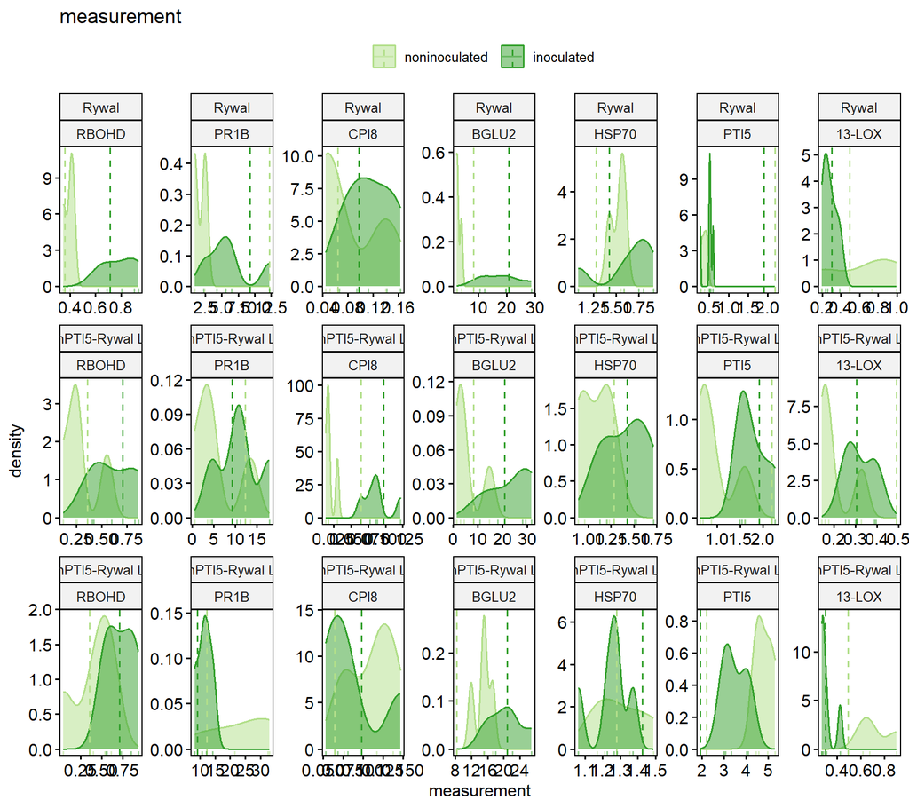

```
## ####  ####
## Distribution tests
## ####  ####
```

```
## # A tibble: 21 × 8
##        n Genotype        transcript Shapiro_Wilk_BH Anderson_Darling_BH
##    <int> <fct>           <fct>                <dbl>               <dbl>
##  1     8 Rywal           RBOHD                0.680               0.689
##  2     7 Rywal           PR1B                 0.680              NA
##  3     8 Rywal           CPI8                 0.680               0.689
##  4     8 Rywal           BGLU2                0.680               0.689
##  5     8 Rywal           HSP70                0.680               0.689
##  6     8 Rywal           PTI5                 0.680               0.689
##  7     8 Rywal           13-LOX               0.346               0.362
##  8     9 shPTI5-Rywal L2 RBOHD                0.680               0.740
##  9     8 shPTI5-Rywal L2 PR1B                 0.680               0.689
## 10     9 shPTI5-Rywal L2 CPI8                 0.680               0.689
## 11     9 shPTI5-Rywal L2 BGLU2                0.680               0.689
## 12     9 shPTI5-Rywal L2 HSP70                0.680               0.689
```

[output cut: 35 more lines]

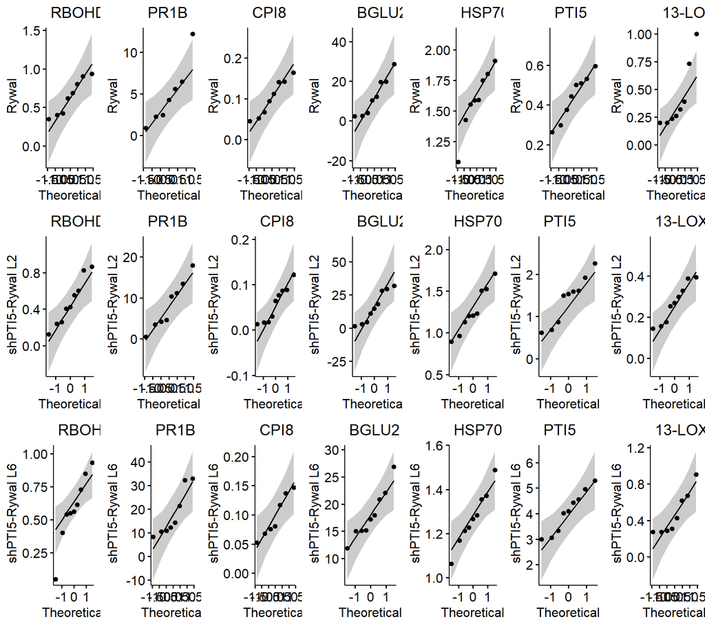

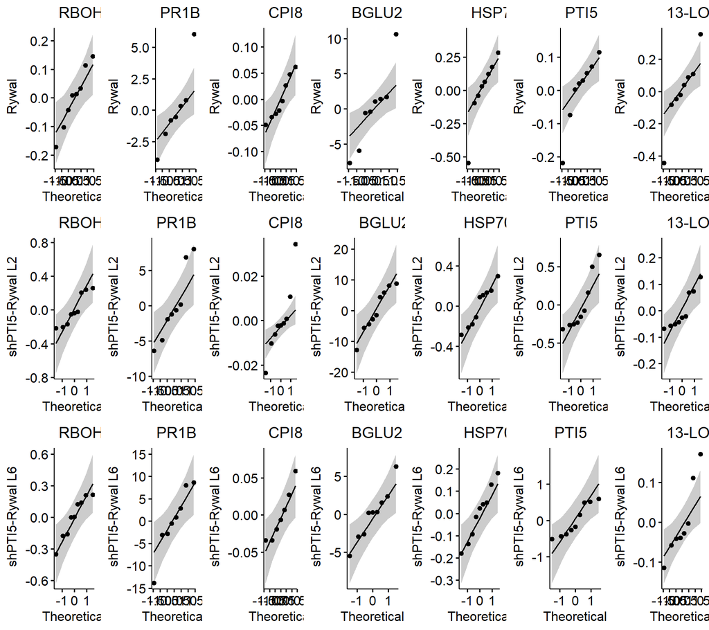

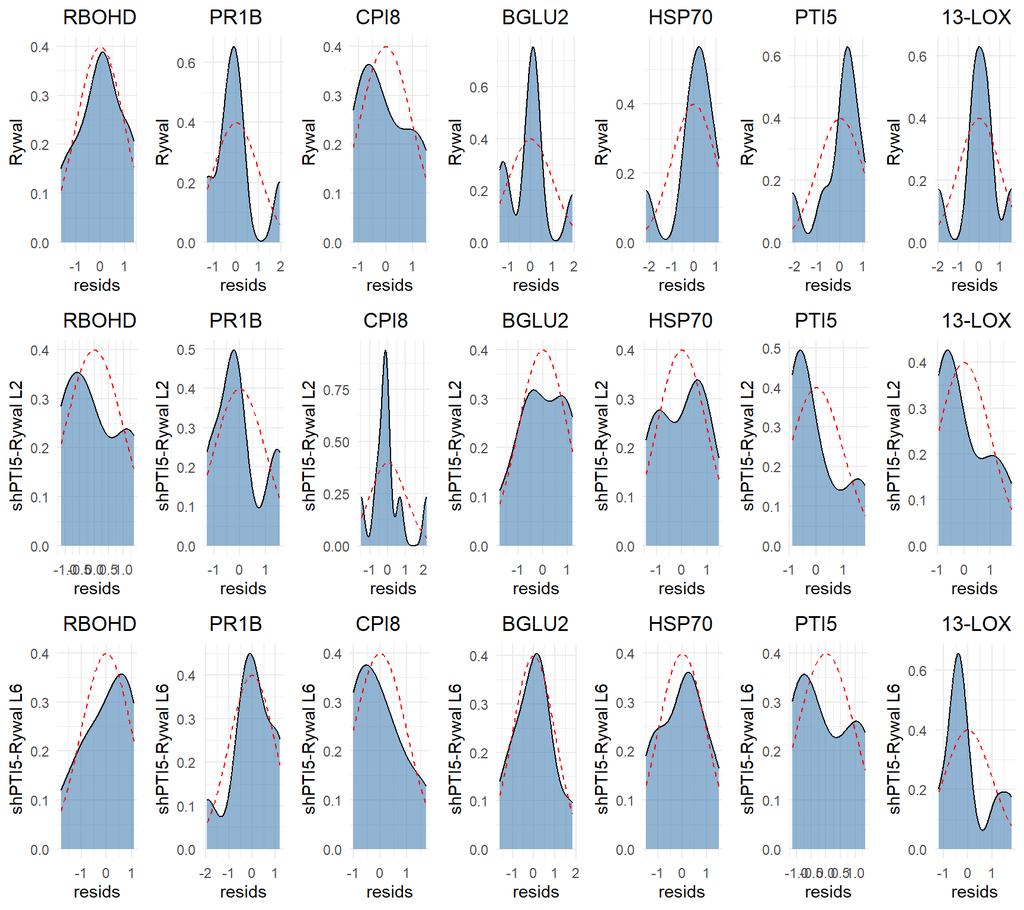

```
## ####  ####
## Test for homogeneity of variance across groups
## ####  ####
## ####  ####
## Levene
## ####  ####
## # A tibble: 21 × 6
##    Genotype        transcript   df1   df2 statistic     p
##    <fct>           <fct>      <int> <int>     <dbl> <dbl>
##  1 Rywal           RBOHD          1     6   3.77    0.100
##  2 Rywal           PR1B           1     5   0.698   0.442
##  3 Rywal           CPI8           1     6   0.0153  0.906
##  4 Rywal           BGLU2          1     6   2.76    0.148
##  5 Rywal           HSP70          1     6   0.925   0.373
##  6 Rywal           PTI5           1     6   0.144   0.718
##  7 Rywal           13-LOX         1     6   3.32    0.118
##  8 shPTI5-Rywal L2 RBOHD          1     7   0.581   0.471
##  9 shPTI5-Rywal L2 PR1B           1     6   0.00169 0.969
## 10 shPTI5-Rywal L2 CPI8           1     7   1.39    0.278
## # ℹ 11 more rows
## ####  ####
## Brown-Forsythe
## ####  ####
## # A tibble: 21 × 6
##    Genotype        transcript   df1   df2 statistic     p
##    <fct>           <fct>      <int> <int>     <dbl> <dbl>
##  1 Rywal           RBOHD          1     6   3.77    0.100
##  2 Rywal           PR1B           1     5   0.698   0.442
##  3 Rywal           CPI8           1     6   0.0153  0.906
##  4 Rywal           BGLU2          1     6   2.76    0.148
##  5 Rywal           HSP70          1     6   0.925   0.373
##  6 Rywal           PTI5           1     6   0.144   0.718
##  7 Rywal           13-LOX         1     6   3.32    0.118
##  8 shPTI5-Rywal L2 RBOHD          1     7   0.581   0.471
##  9 shPTI5-Rywal L2 PR1B           1     6   0.00169 0.969
## 10 shPTI5-Rywal L2 CPI8           1     7   1.39    0.278
## # ℹ 11 more rows
## ####  ####
## Fligner
## ####  ####
```

[output cut: 34 more lines]

```
## ####  ####
## # A tibble: 21 × 9
##    .y.         group1   group2 effsize Genotype transcript    n1    n2 magnitude
##  * <chr>       <chr>    <chr>    <dbl> <fct>    <fct>      <int> <int> <ord>
##  1 measurement noninoc… inocu…  -3.99  Rywal    RBOHD          3     5 large
##  2 measurement noninoc… inocu…  -1.63  Rywal    PR1B           2     5 large
##  3 measurement noninoc… inocu…  -0.793 Rywal    CPI8           3     5 moderate
##  4 measurement noninoc… inocu…  -2.93  Rywal    BGLU2          3     5 large
##  5 measurement noninoc… inocu…  -0.443 Rywal    HSP70          3     5 small
##  6 measurement noninoc… inocu…  -1.04  Rywal    PTI5           3     5 large
##  7 measurement noninoc… inocu…   1.24  Rywal    13-LOX         3     5 large
##  8 measurement noninoc… inocu…  -1.65  shPTI5-… RBOHD          4     5 large
##  9 measurement noninoc… inocu…  -1.01  shPTI5-… PR1B           4     4 large
## 10 measurement noninoc… inocu…  -4.25  shPTI5-… CPI8           4     5 large
## # ℹ 11 more rows
```

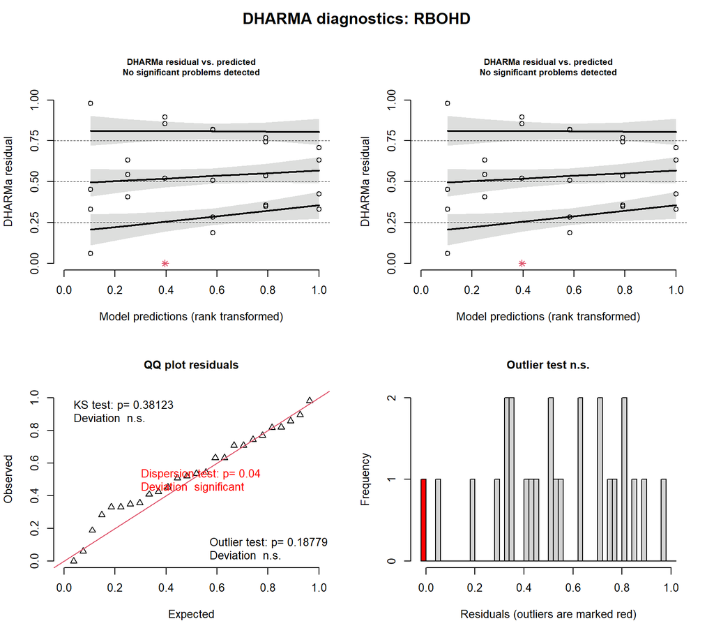

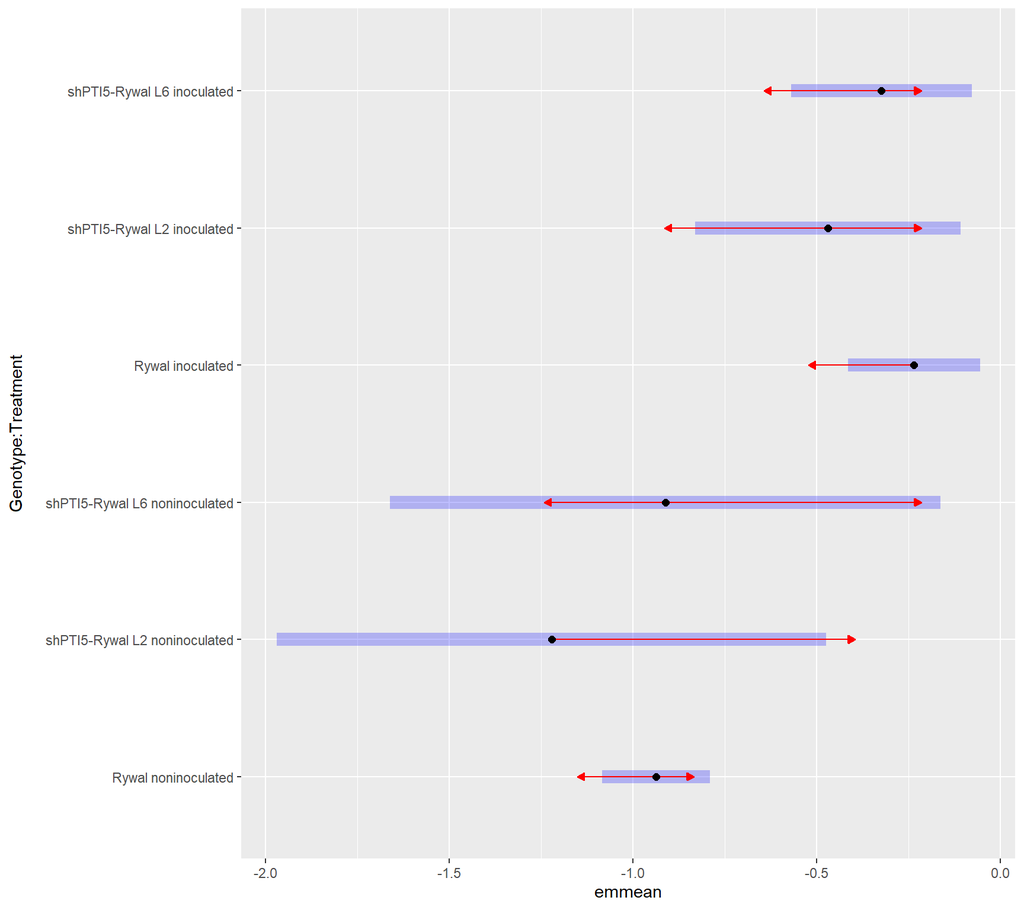

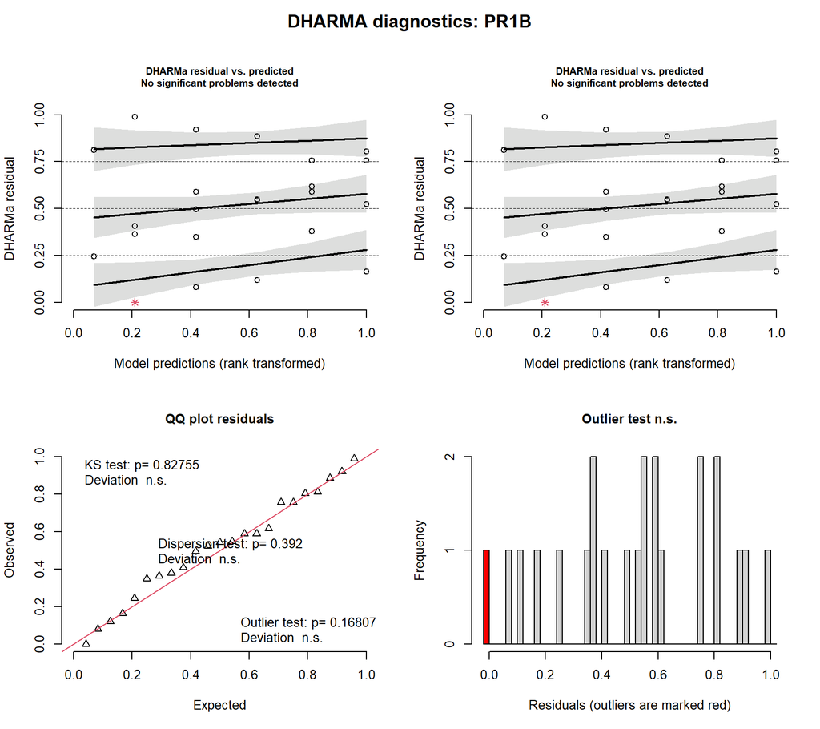

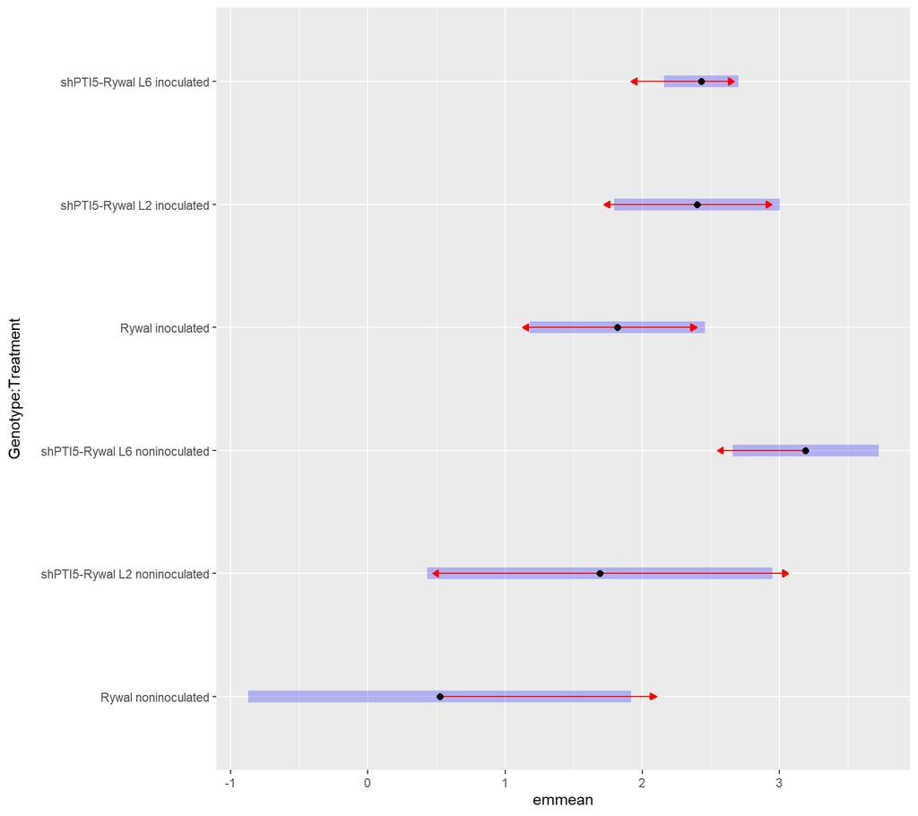

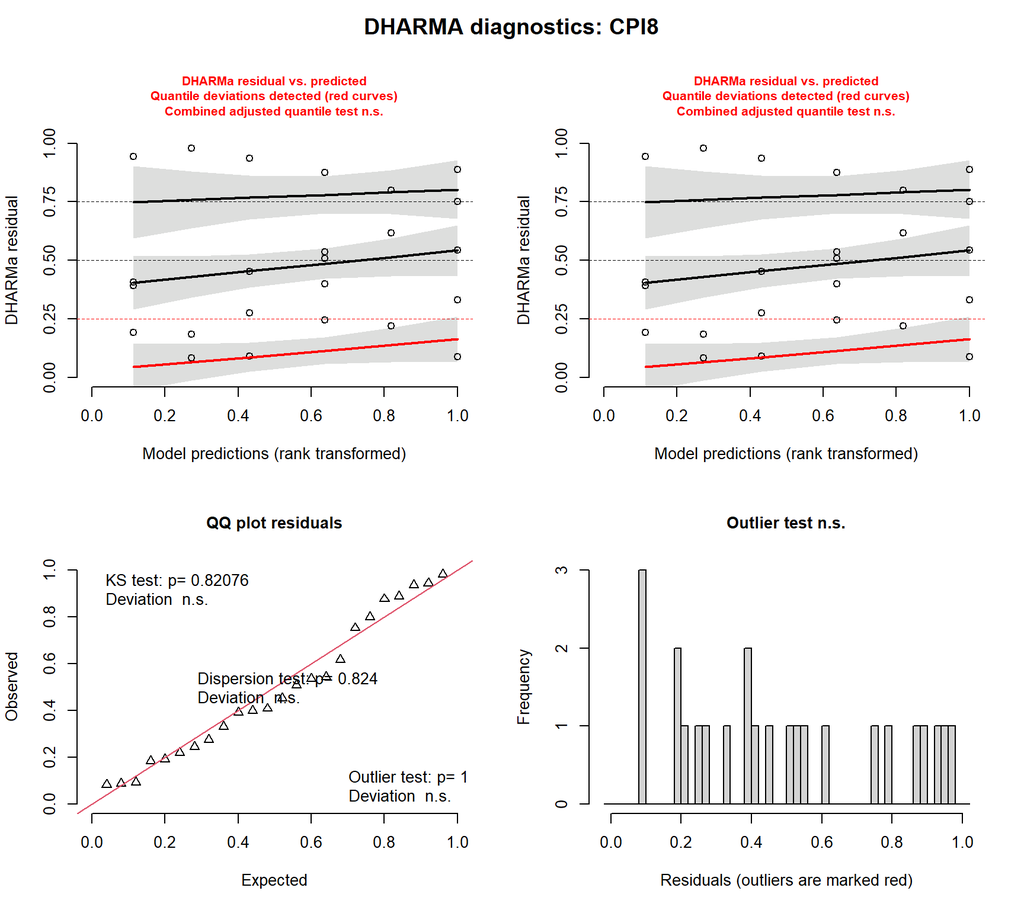

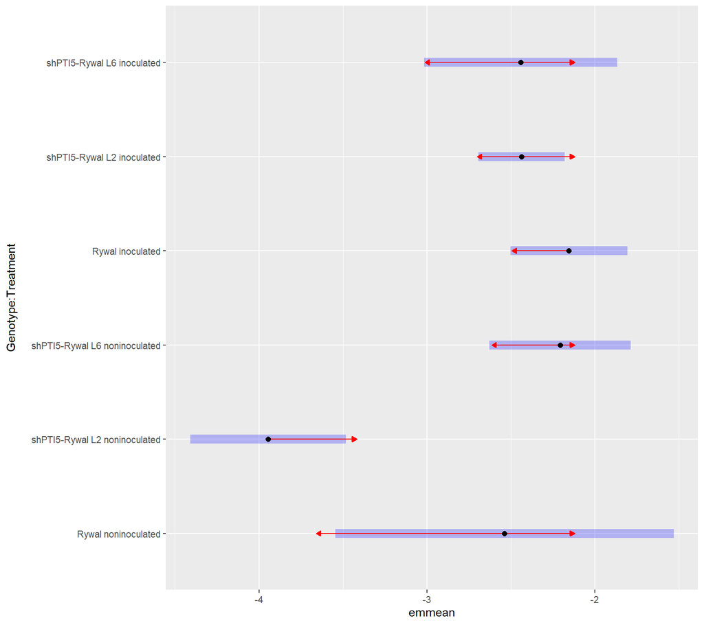

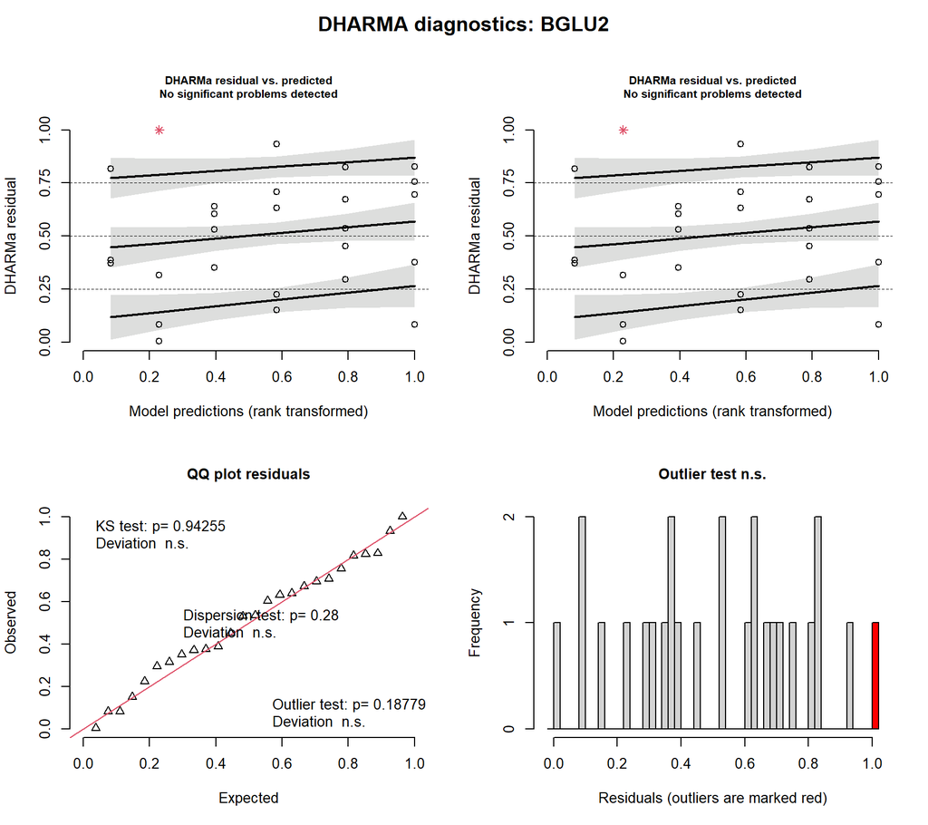

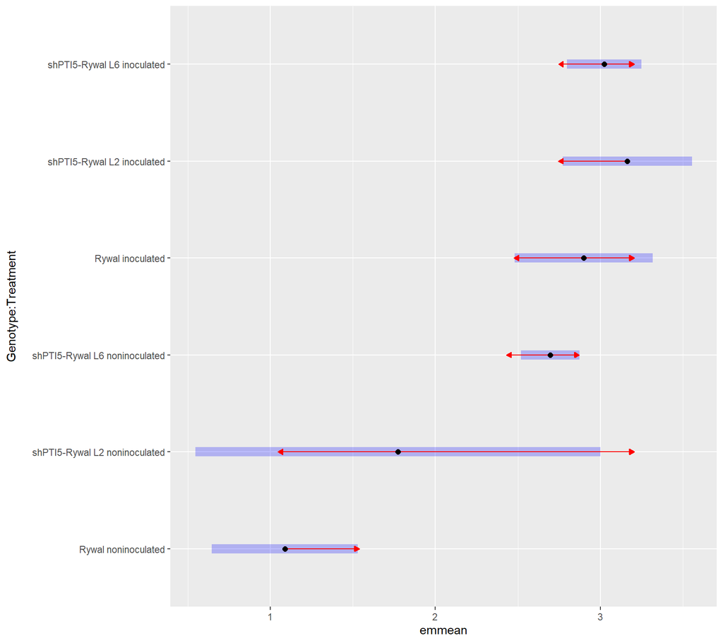

[8 more figures not shown]

```r
max_per_transcript = amf %>%
  dplyr::group_by(transcript) %>%
  # dplyr::summarise(max_scaled = max(scaled, na.rm = TRUE), .groups = "drop")
  dplyr::summarise(max_scaled = max(measurement, na.rm = TRUE), .groups = "drop")
group2_names = setdiff(max_per_transcript$transcript, group1_names)
y_scales1 = build_y_scales_for(group1_names, max_per_transcript)
y_scales2 = build_y_scales_for(group2_names, max_per_transcript)


result = test_and_plot(data_long_raw = amf
                       , myorder = myorder
                       , pal = p
                       , what = "AMF"
                       , plot_gene_expression_func = plot_gene_expression
                       , groupvars = c("Treatment", "Genotype", "transcript")
                       , y_scales1
                       , y_scales2
                       )
```

```r
res = result$stat.test[, grep("transcript|group1|group2|^p$|p\\.", colnames(result$stat.test))]
print(res[res$p.adj.signif != 'ns', ])
```

```
##     transcript                        group1                        group2
## 3        RBOHD           Rywal noninoculated              Rywal inoculated
## 5        RBOHD           Rywal noninoculated    shPTI5-Rywal L6 inoculated
## 17        PR1B           Rywal noninoculated shPTI5-Rywal L6 noninoculated
## 25        PR1B shPTI5-Rywal L6 noninoculated              Rywal inoculated
## 36        CPI8 shPTI5-Rywal L2 noninoculated shPTI5-Rywal L6 noninoculated
## 37        CPI8 shPTI5-Rywal L2 noninoculated              Rywal inoculated
## 38        CPI8 shPTI5-Rywal L2 noninoculated    shPTI5-Rywal L2 inoculated
## 39        CPI8 shPTI5-Rywal L2 noninoculated    shPTI5-Rywal L6 inoculated
## 47       BGLU2           Rywal noninoculated shPTI5-Rywal L6 noninoculated
## 48       BGLU2           Rywal noninoculated              Rywal inoculated
## 49       BGLU2           Rywal noninoculated    shPTI5-Rywal L2 inoculated
## 50       BGLU2           Rywal noninoculated    shPTI5-Rywal L6 inoculated
## 61       HSP70           Rywal noninoculated shPTI5-Rywal L2 noninoculated
## 65       HSP70           Rywal noninoculated    shPTI5-Rywal L6 inoculated
```

[output cut: 45 more lines]

```r
cat("", file = fr, append = TRUE, sep = "\n")
output_text = "EMM"
cat(output_text, file = fr, append = TRUE, sep = "\n")
header = paste(colnames(res), collapse = "\t")
cat(header, file = fr, append = TRUE, sep = "\n")
output_text = apply(as.data.frame(tibble::as_tibble(res)), 1, function(row) paste(row, collapse = "\t"))
cat(output_text, file = fr, append = TRUE, sep = "\n")
cat("", file = fr, append = TRUE, sep = "\n")
cat("", file = fr, append = TRUE, sep = "\n")




ggsave(
  filename = file.path(my_dir, "AMF-addOn_1.pdf"),
  plot = result$plot1,
  device = pdf,
  path = NULL,
  scale = 1,
  width = 6,
  height = 8,
  units = c("in"),
  dpi = 900,
  limitsize = TRUE,
  bg = NULL
)

ggsave(
  filename = file.path(my_dir, "AMF-addOn_2.pdf"),
  plot = result$plot2,
  device = pdf,
  path = NULL,
  scale = 1,
  width = 15,
  height = 8,
  units = c("in"),
  dpi = 900,
  limitsize = TRUE,
  bg = NULL
)
```